# Statistical inference with the GSS data

## Setup

### Load packages

```r
library(ggplot2)
library(dplyr)
library(statsr)
```

### Load data

```r
load("course2_week5.Rdata")
dim(gss)
```

```
## [1] 57061   114
```

## Part 1: Data

Generabizability - The data collected is indeed generelizable.This is because random sampling was used to collect data from a house and random houses were selected until the sample size was met.This shows that the data could be generalizable to entire population.

However the data is not completely accurate.There could be many biases involved in the survey such as non-response bias where the house does not wish to participate in the survey.

Causality - This data is not causal.Since this data was randomnly sampled and random assignment was not used we can conclude that the results obtained from the data would not imply causation.They could definetely be correlated but not causal in nature.

## Part 2: Research question

Research Question:

Is the age and religious inclination of an individual correlated in any fashion? This is the research question that I would like to address and find the solution to.According to my belief as the age increases the religious inclination of a person increase.This means that older people should be more religious compared to the younger generation.

Variables used: age,attend

Interest - I believe that this analysis could give a direct comparison as to how priorities of humans change with their age which might help in analysing human behaviour. * * *

## Part 3: Exploratory data analysis

In this data I have divided age into 3 groups: 1. If the age of respondent is less than 35 then he/she is classifide as “young” 2.If the age is>35 and less than 60 then the respondent is classified as “mid-age” 3.If the age is >60 then the respondent belongs to “oldage” category

Similarly for the variable attend I have classified the variable into 3 levels namely: 1.If the respondent attends religioous services atmost once a year then the person is classified as “not religios” 2.If the person attends services several times a month then he/she is classified as “slightly religious” 3.If the person attends services every week then he/she is classified as “highly religious”

```r
rsq1<-gss[,c("age","attend")]
rsq1<-rsq1%>%
  mutate(age_category = ifelse(age>60,"oldage",ifelse(age>35,"midage","young")))
head(rsq1)
```

```
##   age       attend age_category
## 1  23  Once A Year        young
## 2  70   Every Week       oldage
## 3  48 Once A Month       midage
## 4  27         <NA>        young
## 5  61         <NA>       oldage
## 6  26  Once A Year        young
```

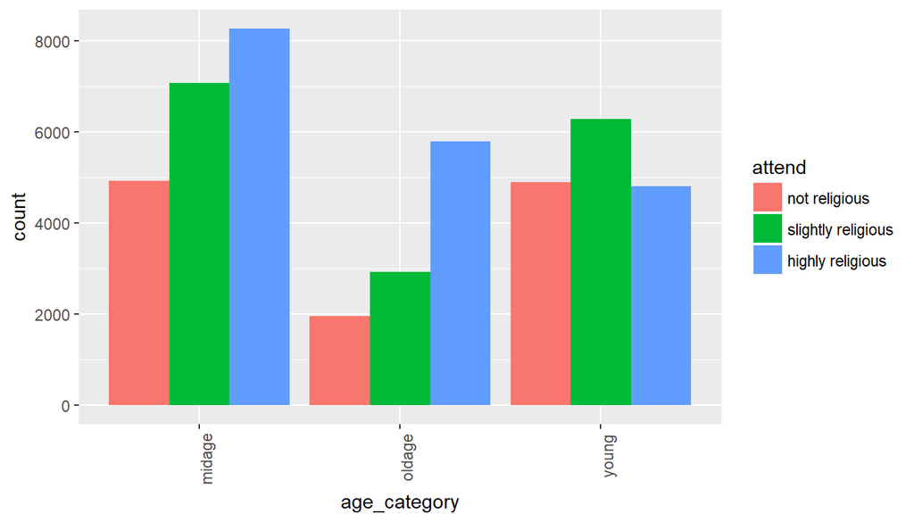

```r
levels(rsq1$attend)[7:9]<-"highly religious"
levels(rsq1$attend)[1:3]<-"not religious"
levels(rsq1$attend)[2:4]<-"slightly religious"
ggplot(data =na.omit(rsq1),aes(x=age_category,fill = attend))+
  theme(axis.text.x = element_text(angle = 90, hjust = 0.9)) +
  geom_histogram(stat="count",position="dodge")
```

```r
rsq1<-within(rsq1,rm(age))
```

```r
rsq1_table<-table(rsq1)#<-rowSums(table(rsq1))
rsq1_table<-cbind(rsq1_table,rowSums(rsq1_table))
rsq1_table<-rbind(rsq1_table,colSums(rsq1_table))
colnames(rsq1_table)[4]<-"total_count_of_religious_people"
rownames(rsq1_table)[4]<-"total_count_based_on_age"
rsq1_table
```

```
##                          midage oldage young
## not religious              4932   1963  4900
## slightly religious         7073   2926  6283
## highly religious           8271   5786  4813
## total_count_based_on_age  20276  10675 15996
##                          total_count_of_religious_people
## not religious                                      11795
## slightly religious                                 16282
## highly religious                                   18870
## total_count_based_on_age                           46947
```

The table gives a numerical standpoint on the values of all the levels in the 2 categorical variables used.These calculations are used further to calculate the chi square statistic for the chi square independence tets.

```r
prop.table(table(rsq1),1)*100
```

```
##                     age_category
## attend                 midage   oldage    young
##   not religious      41.81433 16.64265 41.54303
##   slightly religious 43.44061 17.97077 38.58863
##   highly religious   43.83148 30.66243 25.50609
```

A percentage representation of the same table as described above. * * *

## Part 4: Inference

Hypothesis:

The null hypothesis states that there is no correlation between the age and the religious inclination of a person.This means that they are independent of each other.

The alternative hypothesis states that there is a relation between the age and religious inclination of an individual.

Method used:

Since I have 2 categorical variables with more than 2 levels I have used chi-squared independence test to determine if there is a relation between the the age and religious inclination of an individual.

Conditions for Chi square independence test:

Independence - All the sampled observations are independent of each other since they: 1. Randomnly sampled(since it is a survey) 2. The sampled population is definetely less than 10% of the entire American population 3. Each case is contributing only to a prticular cell i.e. every cell is uniquely identifiable and there is no dependence between 2 cells.

```r
save<-0
for(i in 1:4){
  save[i] = rsq1_table[i,"total_count_of_religious_people"]/rsq1_table[4,"total_count_of_religious_people"]
}
rsq1_table_inf = cbind(rsq1_table,save)
colnames(rsq1_table_inf)[5]<-"expected % of religious inclination"
expected_midage<-0
expected_oldage<-0
expected_young<-0
for(i in 1:4){
  expected_midage[i] = ceiling(rsq1_table_inf[i,"expected % of religious inclination"]*rsq1_table_inf[4,"midage"])
  expected_oldage[i] = ceiling(rsq1_table_inf[i,"expected % of religious inclination"]*rsq1_table_inf[4,"oldage"])
  expected_young[i] = ceiling(rsq1_table_inf[i,"expected % of religious inclination"]*rsq1_table_inf[4,"young"])
}
#rsq1_table_inf[1,"expected % of religious inclination"]
```

```r
rsq1_table_inf<-cbind(rsq1_table_inf,expected_midage)
rsq1_table_inf<-cbind(rsq1_table_inf,expected_oldage)
rsq1_table_inf<-cbind(rsq1_table_inf,expected_young)
```

Attaching expected values to the table

```r
rsq1_table_inf
```

```
##                          midage oldage young
## not religious              4932   1963  4900
## slightly religious         7073   2926  6283
## highly religious           8271   5786  4813
## total_count_based_on_age  20276  10675 15996
##                          total_count_of_religious_people
## not religious                                      11795
## slightly religious                                 16282
## highly religious                                   18870
## total_count_based_on_age                           46947
##                          expected % of religious inclination
## not religious                                      0.2512408
## slightly religious                                 0.3468166
## highly religious                                   0.4019426
## total_count_based_on_age                           1.0000000
##                          expected_midage expected_oldage expected_young
## not religious                       5095            2682           4019
## slightly religious                  7033            3703           5548
## highly religious                    8150            4291           6430
## total_count_based_on_age           20276           10675          15996
```

The above table contains the expected value and the observed value which is required for calculation of the p-value in chi-square independence test.The expected_midage,expected_young and expected_oldage contain the expected values.For cross checking purposes if we add expected_midage + expected_oldage + expected_young together we get the value equalto the total_count_of_religious_people. If in case the value does not exactly match this is beacause I have used a ceiling function to roundoff the values.However this rounding off does not have a major impact on the p value.

```r
x_square<-0
for(i in 1:3){
  x_square = x_square + (rsq1_table_inf[i,"midage"]-rsq1_table_inf[i,"expected_midage"]) ^2 /rsq1_table_inf[i,"expected_midage"]
  x_square = x_square + (rsq1_table_inf[i,"oldage"]-rsq1_table_inf[i,"expected_oldage"]) ^2 /rsq1_table_inf[i,"expected_oldage"]
  x_square = x_square + (rsq1_table_inf[i,"midage"]-rsq1_table_inf[i,"expected_midage"]) ^2 /rsq1_table_inf[i,"expected_young"]
}
x_square
```

```
## [1] 893.0682
```

```r
pchisq(x_square,4,lower.tail=FALSE)
```

```
## [1] 5.290971e-192
```